# Analyse bioinformatique des données moléculaires à haut débit en Oncologie

02 Mars 2026

## Analyse bioinformatique des données moléculaires à haut débit en Oncologie

### Contexte général des analyses **OMIQUES**

### Analyse de **variants structuraux** par NGS (*DNA-seq*)

### Analyse du **transcriptome** par NGS (*RNA-seq*)

### Analyse fonctionnelle des gènes (enrichissement)

## Je me présente

- Ghislain Bidaut
- IR, Responsable de la **plateforme Cibi** au **Centre de Recherche en Cancérologie de Marseille**
- Contact ghislain.bidaut@inserm.fr
- Site web http://cibi.marseille.inserm.fr

## Qu’est ce que la bioinformatique ?

Qu’évoque pour vous le terme de “Bioinformatique” ?

## Qu’est ce que la bioinformatique ?

- **Apparition en 1970**: B Hesper et P Hogeweg, « Bioinformatica: een werkconcept », *Kameleon*, vol. 1, no 6, 1970, p. 28–29

La bio-informatique est constituée par l’ensemble des concepts et des techniques nécessaires à l’interprétation informatique de l’information biologique. Plusieurs champs d’application ou sous-disciplines de la bio-informatique se sont constitués (*Wikipedia*):

- **La bio-informatique des séquences**
- **La bio-informatique structurale**
- **La bio informatique des réseaux**
- **La bio-informatique statistique et des populations**

## Projet du séquençage du Génome Humain

- **Idée** lancée en 1985 par 3 scientifiques, **Renatto Dulbecco**, **Robert Sinsheimer** (directeur de UCSC) et **Charles DeLisi**, qui financera le projet (Directeur dept. de biologie du *Département de l’Energie US*)
- **Séquençage** lancé en 1988 par le *National Research Council*. En suisse est créé HUGO (*Human Genome Organisation*) pour la coordination.
- En 1998, Craig Venter, crée *Celera Genomics* avec pour objectif le **séquençage en 3 ans** par séquençage *Shotgun* et le brevetage du génome (!).
- En 2000, la complétion du séquençage est annoncé pour le Consortium et Celera Genomics (match nul) par le président B. Clinton. Coût: 3 Milliards de dollars.
- *Celera Genomics* avouera avoir utilisé les données du Consortium pour son propre assemblage, mais reproduira un séquençage *de Novo* 3 ans plus tard…
- Publication des séquences brutes en 2001 et des séquences finales en 2004. -> Aujourd’hui, ces données constituent un **pilier de la médecine de précision en oncologie**.

## NGS pour le diagnostic en cancérologie

- Aujourd’hui, le séquençage est utilisé en **routine** pour élaborer le **profil moléculaire** des patients atteint de cancer.
- La diminution des coûts de séquencage et l’évolution de la technologie a permis de couvrir des régions génomiques plus grande et donc de tester des panels plus élaborés.
- La tendance actuelle en **diagnostique** est l’utiisation de panels, considérés actuellement **plus fiables** (profondeur de séquençage supérieure) et **plus efficaces en termes de coûts**.
- Le challenge actuel en bioinformatique réside dans la mise au point de **nouveaux outils bio-informatiques** pour assister les biologistes dans l’analyse des variants.

## Applications concrètes en oncologie

- **Applications à visée diagnostique pour la clinique**: analyse de panels de gènes pour l’étude de mutations **constitutionnelles** et **tumorales**.
- **Recherche de mutations à visée de recherche**: Analyse de panels *larges* ou *d’exomes* (complet) à visée de découverte.

**But:** recherche de **mutations** dans des **gènes d’interêt** pour la prise en charge personnalisée du patient.

- Un grand nombre de patients peuvent être analysés **simultanément** et rapidement.
- L’analyse bioinformatique consiste à **aligner les séquences sur le génome de référence** et à **quantifier les changements par rapport à ce génome (variants)** par l’applications de méthodes statistiques.
- L’analyse biologique consiste ensuite à **évaluer la pathogénicité** de ces variants à l’aide de connaissances biologiques préalables (**Bases de données**).

## Rôle central et organisation de la bioinformatique en oncologie

- **Extraction et traitement** des données de séquençage
- **Organisation des données** dans des bases de données labo (LIMS), entrepôts de données de santé (EDS)
- Détection des mutations somatiques, CNV, fusions, anomalies d’expression
- **Annotation** via des bases comme COSMIC, ClinVar, GnomAD
- **Intégration multi-omique** pour relier génomique ↔ transcriptomique ↔ clinique

### Infrastructures et défis

- **Gestion et sécurisation** des données dans les EDS (RGPD)
- **Reproductibilité des analyses** (pipelines, conteneurs, standards bioinformatiques)
- **Collaboration interdisciplinaire** : cliniciens, biologistes, bioinformaticiens, data scientists

## Principe général d’une analyse DNA-seq

[figure not shown]

## Analyse de données *Omiques* en oncologie

- Génomique:
  - **DNA-seq:** recherche de **variants structuraux** et de **fusions**
  - **ChIP-seq:** recherche de sites d’interactions proteines-ADN (Exemple Histones, TFs).
  - **ATAC-seq:** recherche des sites accessibles à la chromatine.
- Transcriptomique:
  - Bulk: **RNA-seq**
  - Analyse en cellule Unique: **scRNA-seq**
- Protéomique: Spectrométrie de masse

## Le DNA-seq et son application en oncologie.

**Applications principales**

- Recherche: Analyse de panels *larges* ou *d’exomes* (complet) à visée de découverte.
- Clinique: analyse de panels restreints à visée diagnostique.

**Interêt du NGS en Oncologie**

- Permet l’étude de mutations **constitutionnelles** et **somatiques à faible pourcentages**.
- Possibilité de traiter des **projets ciblés** ou des panels plus larges, voire **exome complet**.
- Un grand nombre de patients peuvent être analysés **simultanément** et rapidement.
- L’analyse bioinformatique devient **partie intégrante** du processus de traitement.

## Industrialisation du séquençage

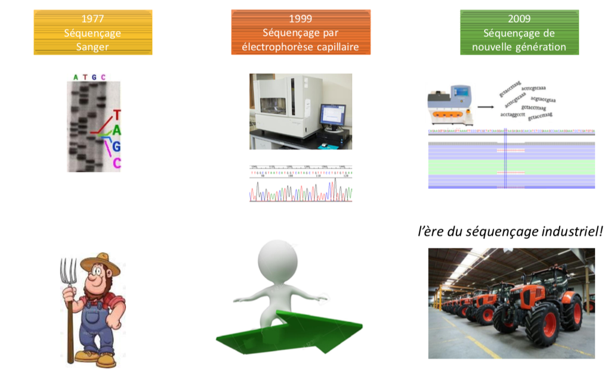

## Principe général du NGS

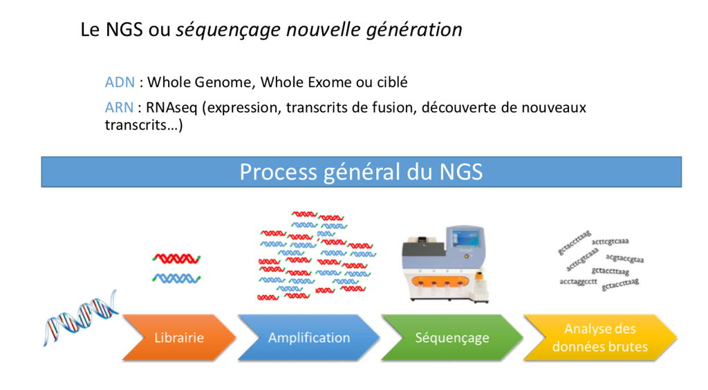

## Echelles en fonction de l’application

[figure not shown]

## Détection de variants structuraux par NGS

## Détection de variants structuraux par NGS

Quelles seraient les étapes bioinformatque d’un pipeline de détection de variants ?

## Détection de variants structuraux par NGS

**But:** recherche de mutations dans des gènes d’interêt pour poser un diagnostique sur un patient.

Etapes de l’analyse bioinformatique:

- **Contrôle Qualité** sur les données brutes (**Obligatoire!**)
- **Alignement des reads** sur le génome de référence
  - Alignement principal.
  - Ré-alignement local pour la recherche d’Indels.
- Appel de **variants**
- **Annotation** et production d’un fichier **VCF** et d’un **compte-rendu**

## Fichiers issus du séquenceur (Fichiers FASTQ)

Ils contiennent les **reads**: petite séquence d’un fragment d’ADN de longueurs plus ou mons fixe.

- **Single-end**
  - Chaque read est indépendant
- **Paired-end**
  - Le séquençage est fait par chaque extrémité de chaque brin. Dans ce cas, les reads sont organisés par paires

```
@HWI-ST865:166:D0C4KACXX:2:1101:1042:1954 1:Y:0:
CNANAAATNAANNNNGNNNNNNNNNANNNNNAAANNNTNNNNNNNNNTNNTGNNNNTTGTTTNNTTGTGGGTTTCTCTGTCCCCN
+
#####################################################################################
@HWI-ST865:166:D0C4KACXX:2:1101:1241:1970 1:N:0:
CCAGCGACACTTGCAGCTTAGGGGCAAGAGGCTCCCACAACACCCTGTGCGATCGGAAGAGCGGTTCAGCAGGGATGCCGCGGCC
+
GFFIGIIIFGEHHIJJJIIGGGHIIBD=BFG?EDECC@FGCHC?BCCBB)53(;;B;?8299?######################
```

## Mesure et encodage qualité: le Phred

Quelques définitions:

- Valeur de qualité exprimés en QPhred
- QPhred = probabilité p d’erreur de mauvaise identification de la base
- \(QPhred = -10.log_{10}(p)\)

Exemple:

- Q20 correspond à une probabilité d’erreur de 1%
- Q30 correspond à une probabilité d’erreur de 0,1%

## Contrôle Qualité par FastQC

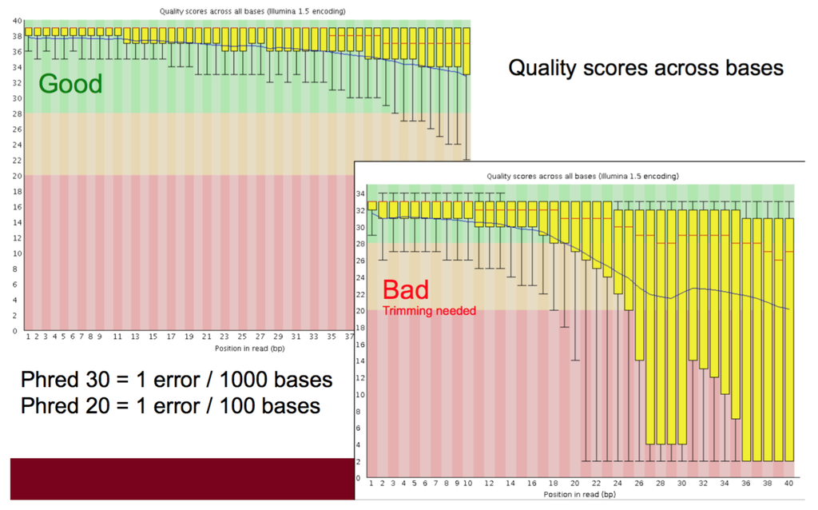

## Détection de variants structuraux par NGS: Départ

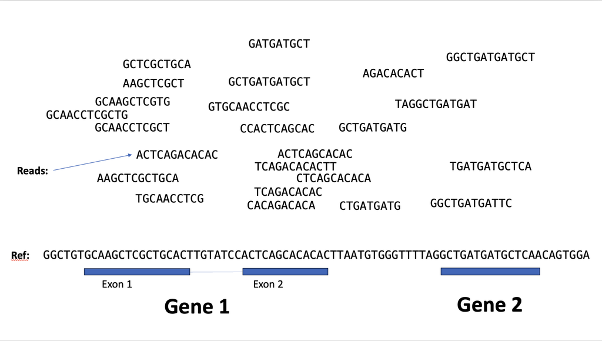

## Détection de variants structuraux par NGS: Alignement

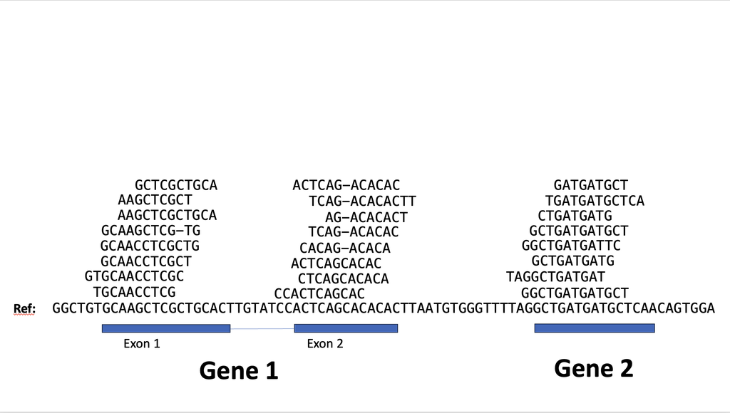

## Détection de variants structuraux par NGS: Détection

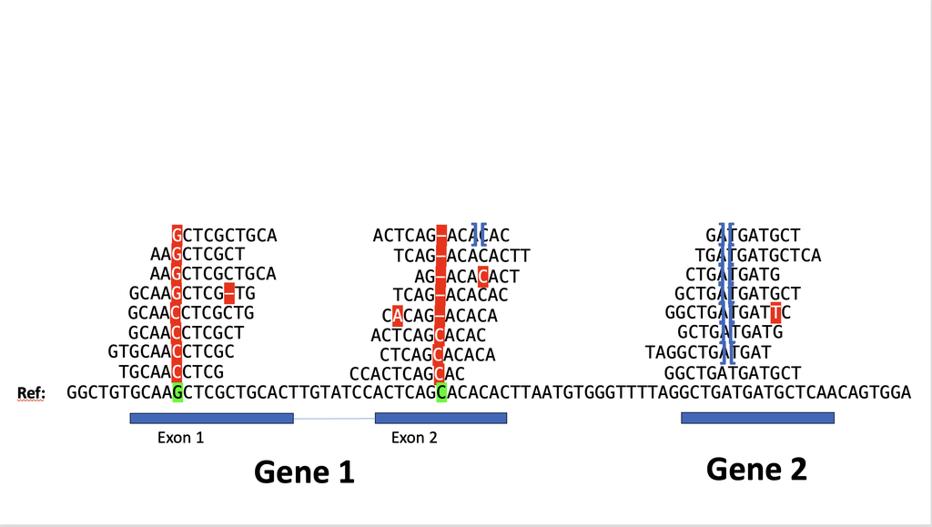

## Détection de variants structuraux par NGS: Type/VAF

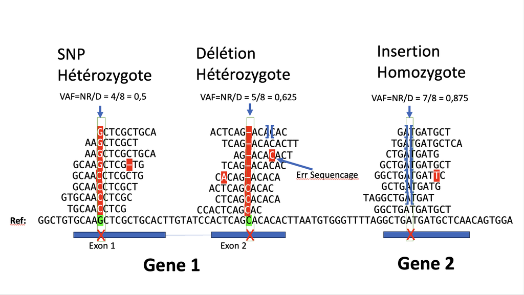

## Détection de variants structuraux par NGS: Résumé

**But:** recherche de **mutations** dans des **gènes d’interêt** pour poser un diagnostique sur un patient.

Etapes de l’analyse bioinformatique:

- **Contrôle Qualité** sur les données brutes (**Obligatoire!**)
- **Alignement des reads** sur le génome de référence
- **Appel de variants** (Recherche des SNP et INDELS)
- **Annotation** et production d’un fichier **VCF** et d’un **compte-rendu**
- \(VAF= Variant AlleleFrequency = \frac{N (Reads Mutés)}{Profondeur}\)

## Production des VCF (Variant Calling Files)

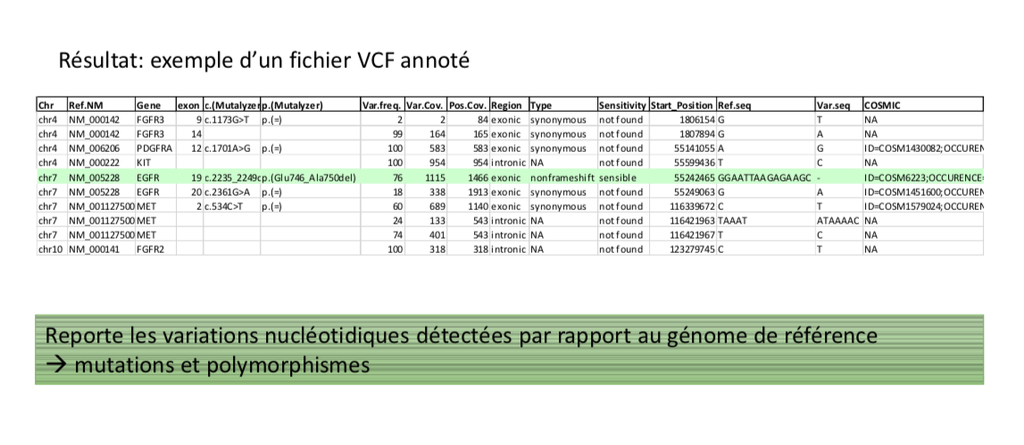

## Visualisation sous IGV

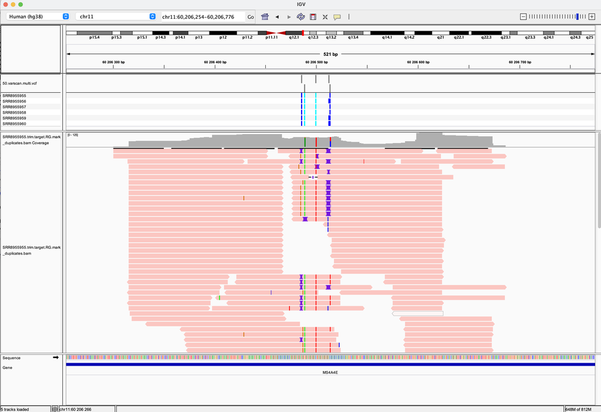

## Quelques définitions: les Reads

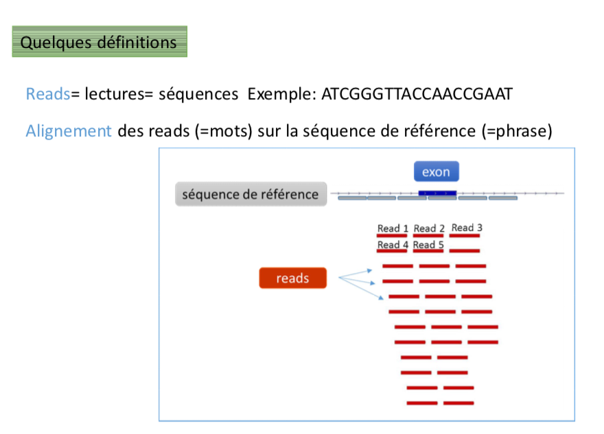

## Quelques définitions: Couverture et profondeur

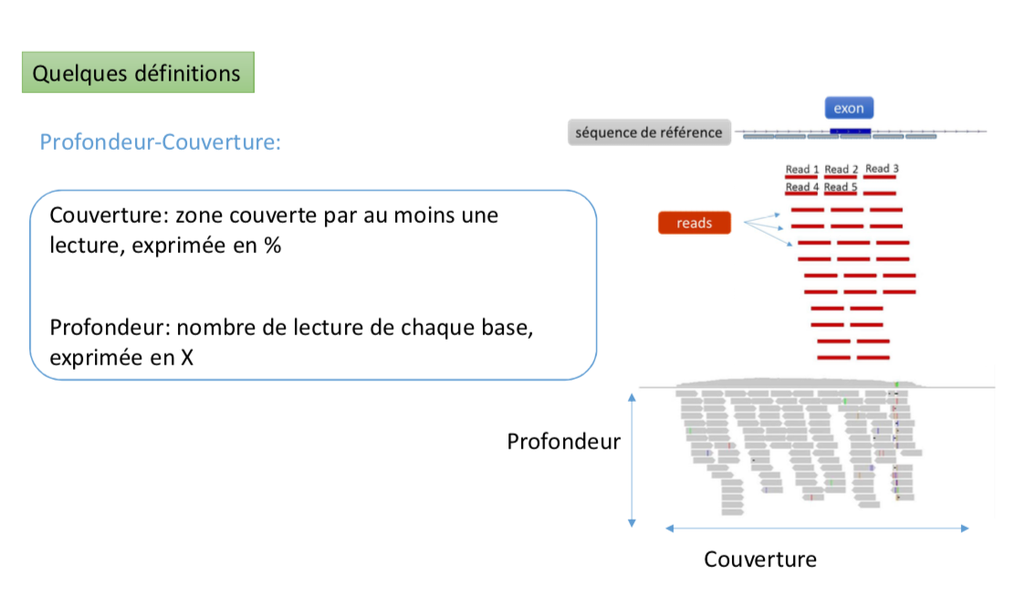

## Quelques définitions: le Phred

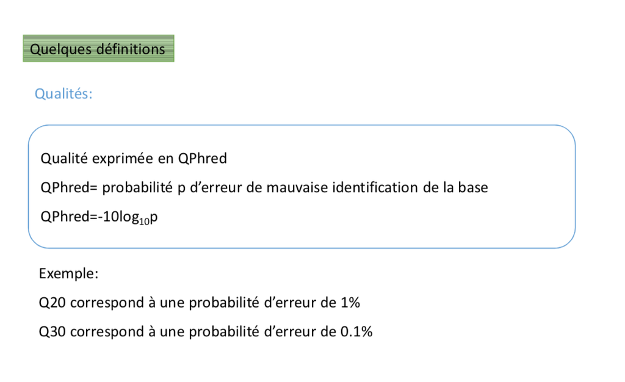

## Analyse de panels: Exemple du panel INCa

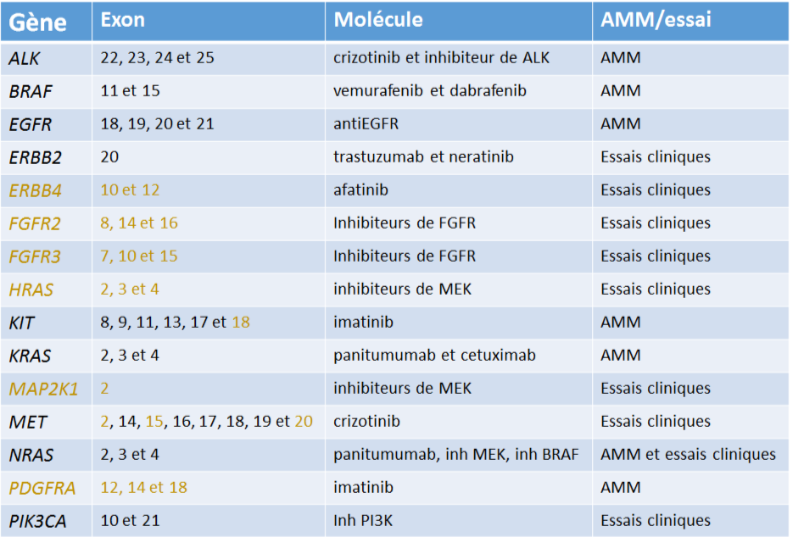

## Du prélèvement au compte-rendu scientifique

Le compte-rendu est fait sur les gènes **prescrits** (dans le cadre du diagnostique)

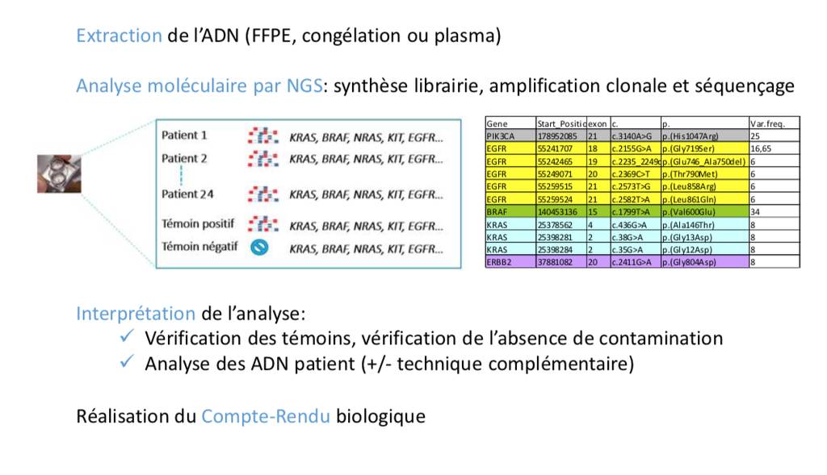

## Annotation des variants

Une fois les SNP et INDELS obtenus, il est nécessaire de les interpréter pour générer un rapport d’analyse.

Pour cela, nous utilisons un *annotateur* de variants. Ce type de programme permet de faire des annotations au niveau des **gènes** et donc de retrouver les gènes à partir des bases de données **RefSeq**, **Ensembl**, etc…

Il en existe des libres (**VEP**, **Annovar**, **SnpEff**) et des commerciaux (**Alamut**)

Les principales bases de données que l’on peut utiliser pour l’annotation sont:

- 1000 Genomes Project
- GnomAD
- COSMIC…

## Rappels sur les extensions de fichiers

- Fichiers de séquences brutes: **.Fastq** (Compressé en zip: **.Fastq.gz**)
- Fichiers de séquences alignées **.BAM** (Binaire - déjà compressé)
- Index de fichiers de séquences alignées **.BAI**
- Génome complet au format FASTA: **.fa**
- Fichiers listant les mutations/Indels: **.VCF** ou **.txt**

## Conclusion de cette partie

- L’utilisation du NGS en oncologie apporte un outil essentiel dans la prise en charge des patients.
- L’analyse bioinformatique fait **partie intégrante** du processus global d’établissement du profil moléculaire d’un patiient.
- Les traitements bioinformatiques sont maintenant quasiment **automatisés** (traitement de séquence, production de variants). Le goulot d’étrangement reste au niveau de **l’analyse de l’impact des variants**.

## Autre application: Analyses NGS du Transcriptome en oncologie

## Analyse RNA-Seq - principe

Analyse de l’expression des gènes = le Transcriptome. C’est une grandeur dynamique.

- Technologie à haut débit précédente: les **Puces à ADN**
- Technologie basée sur le NGS: Le **RNA-Seq**. **Beaucoup d’outils sont communs à ces technologies**

Le NGS appliqué à l’analyse du transcriptome permet:

- Une Meilleure concordance entre plateformes
- Forte sensibilité et meilleure dynamique
- Toutes espèces, toutes régions transcrites
- Une variété d’applications

**Mais…**

- Complexité et coût calculatoire accrus = **pipeline bioinformatique plus complexe**.

## Pipeline bioinformatique RNA-seq

Que seraient pour vous les étapes d’analyse bioinformatique en RNA-seq ?

## Pipeline bioinformatique RNA-seq

- **séquençage**
- **Contrôle qualité**
- **Alignement** sur génome de référence
- **Quantification des valeurs d’expression** (comptage) et normalisation
- **Analyse différentielle** entre conditions expérimentales
- **Visualisation des données** (“diagrammes de chaleur”, “volcano plots”).
- **Analyse fonctionnelle** des gènes (“Gene Set Enrichment Analysis”)

**L’analyse bioinformatique fait partie intégrante du processus de traitement**.

**Plusieurs questions possibles sur une analyse RNA-Seq:**

- Assemblage de transcriptome *de novo*
- Analyse de l’épissage alternatif
- Découverte des gènes de fusion
- Analyse différentielle **supervisée**
- Analyse d’expression **non supervisée**.

## Exemple d’application: recherche de gènes différentiellement exprimés

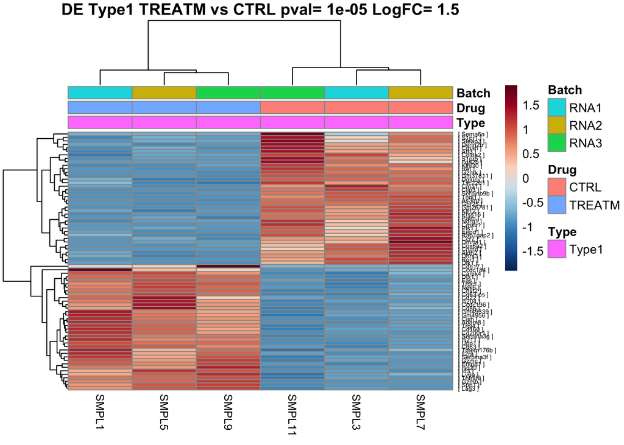

## Découverte de classes de cancers par analyse non supervisée

Exemple de la découverte des sous types moléculaires dans le cancer du sein (Sørlie, Perou et al, *PNAS* 2001).

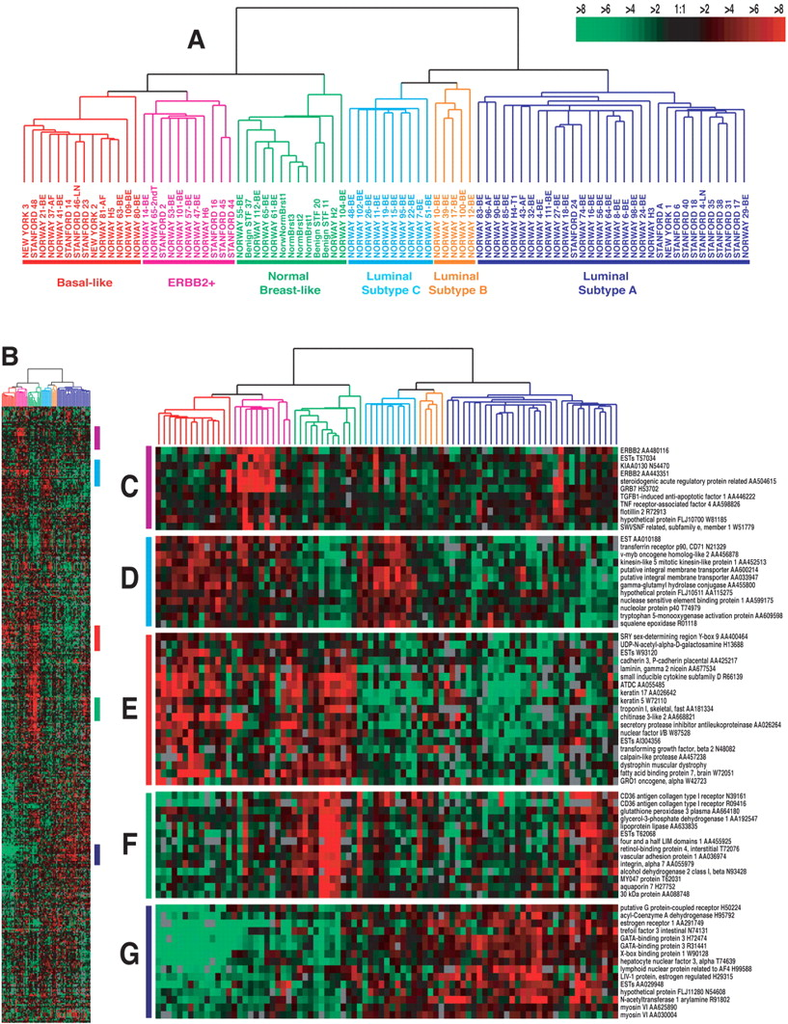

## Alignement et comptage des séquences: Départ

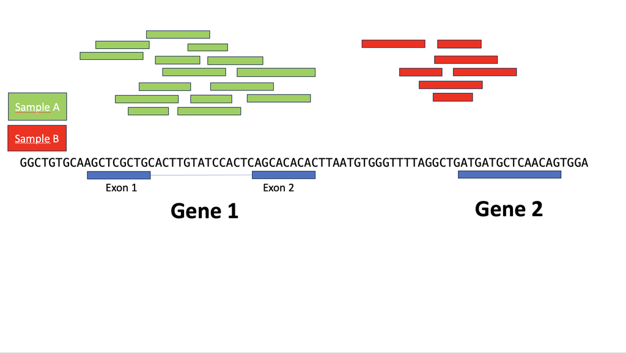

## Alignement et comptage des séquences: Alignement

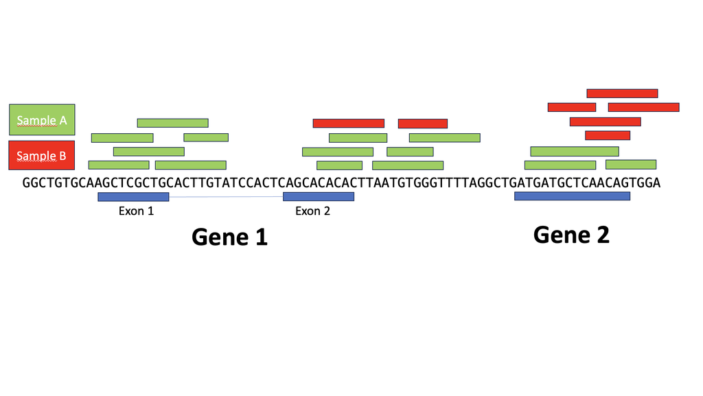

## Alignement et comptage des séquences: Comptage Exons

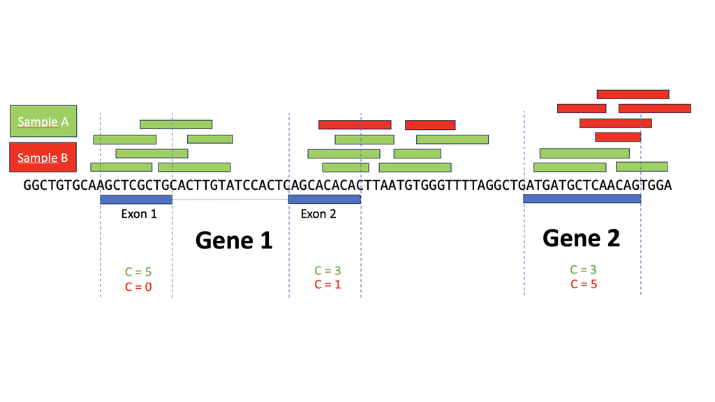

## Alignement et comptage des séquences: Comptage Gènes

[figure not shown]

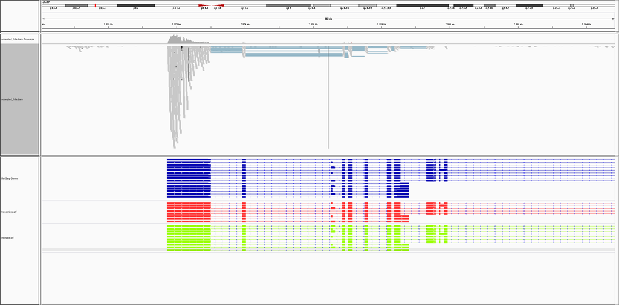

## Analyse de séquence avec IGV

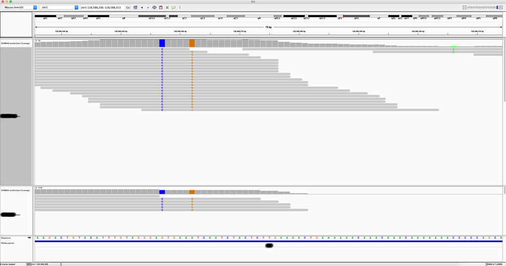

## Analyse différentielle

L’objectif est d’établir quels sont les gènes **différentiellement exprimés** entre plusieurs conditions expérimentales, par exemple, un *contrôle* et un *traitement*. C’est une analyse **supervisée**.

Pour cela, un **test statistique** est utilisé. Rappel: un test statistique est la vérification d’une hypothèse nulle *H0*.

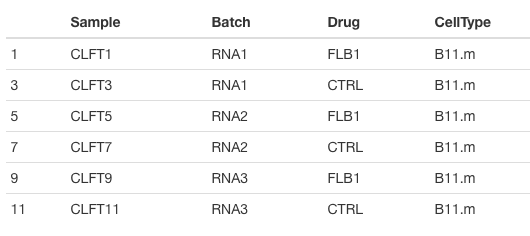

## Quelques définitions: Couverture et profondeur

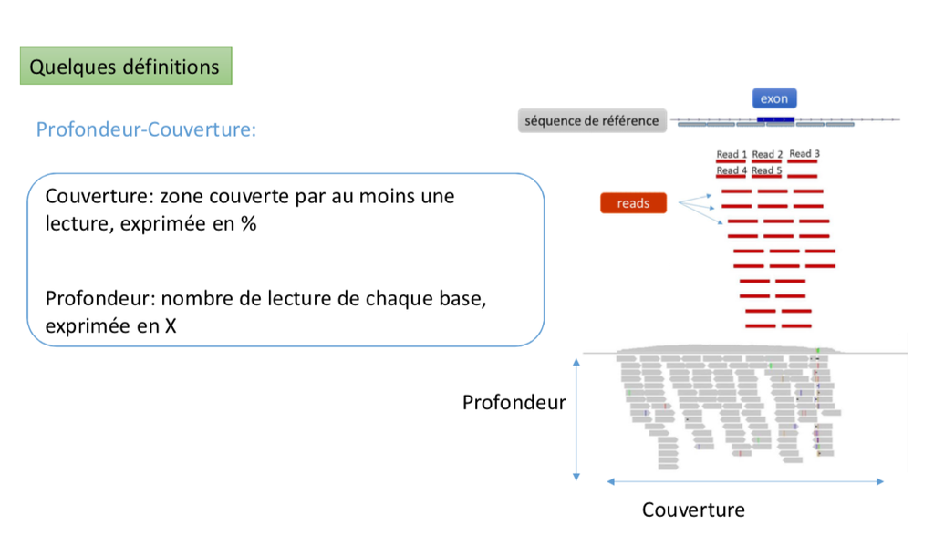

## Annotation du génome de référence

Les annotations du génome de référence sont disponibles sous forme de fichiers **GFF**/**GTF**ou **BED** auprès de Ensembl (BioMart - https://www.ensembl.org/info/data/ftp/index.html) ou NCBI (https://www.ncbi.nlm.nih.gov/refseq/).

```
#!genome-build GRCh38.p13
#!genome-version GRCh38
#!genome-date 2013-12
#!genome-build-accession NCBI:GCA_000001405.28
#!genebuild-last-updated 2019-06
1   havana  gene    11869   14409   .   +   .   gene_id "ENSG00000223972"; gene_version "5"; gene_name "DDX11L1"; gene_source "havana"; gene_biotype "transcribed_unprocessed_pseudogene";
1   havana  transcript  11869   14409   .   +   .   gene_id "ENSG00000223972"; gene_version "5"; transcript_id "ENST00000456328"; transcript_version "2"; gene_name "DDX11L1"; gene_source "havana"; gene_biotype "transcribed_unprocessed_pseudogene"; transcript_name "DDX11L1-202"; transcript_source "havana"; transcript_biotype "lncRNA"; tag "basic"; transcript_support_level "1";
```

## Comptage

- Sous l’hypothèse que le nombre de reads venant d’un certain gène est proportionnel à l’abondance de son ARN dans la cellule, on veut compter les *reads* venant de chaque gène, transcrit ou exon du génome.
- Il est possible de faire un script ‘maison’ mais il existe maintenant un grand nombre de programmes pour faire cette fonction, notamment **featureCount** de la suite logicielle **SubRead**.
- Les localisations génomiques des transcripts sont données en entrée du programme de comptage, permettant d’assigner les comptages à chaque transcrit.

## Normalisation

**Problème:** Le nombre de *reads* varie par échantillon. Il peut aussi y avoir des artéfact dus à la PCR. Il faut donc **Normaliser** pour rendre les échantillons comparables.

- **RPKM: *Reads Per Kilobase per Million***

\(RPKM(G) = \frac{read(G)}{[\sum Read].longeur(G)}.{10}^{6}.{10}^{3}\)

Variante: **FPKM** pour le Paired-end.

Cette méthode est **très** utilisée **MAIS**:

Elle est inadaptée à la comparaison entre échantillons car on ne peut pas comparer des pourcentages!

## Normalisation TMM

- **TMM - Trimmed mean of M-values**.

C’est une des **normalisations recommandées**.

Au lieu de faire une mise à l’échelle propre à une librairie, TMM calcul un facteur de normalisation global en assumant que la majorité des gènes n’est pas DE et en ne tenant pas compte des valeurs extrêmes.

Le facteur est également fonction de la variance d’expression.

La Normalisaion type TMM ou autre n’est nécessaire **que pour la visualisation** ou **l’exploration globale** des données de comptage.

Les logiciels d’analyse différentielles (**EdgeR** et **DESeq2**) ont leur propre normalisation *intégrée* à la méthode et il n’y a pas besoin d’appliquer de normalisation aux comptages avant un appel à l’une de ces méthodes.

## QC (Quality Control)

Comparaison de la taille de librairies

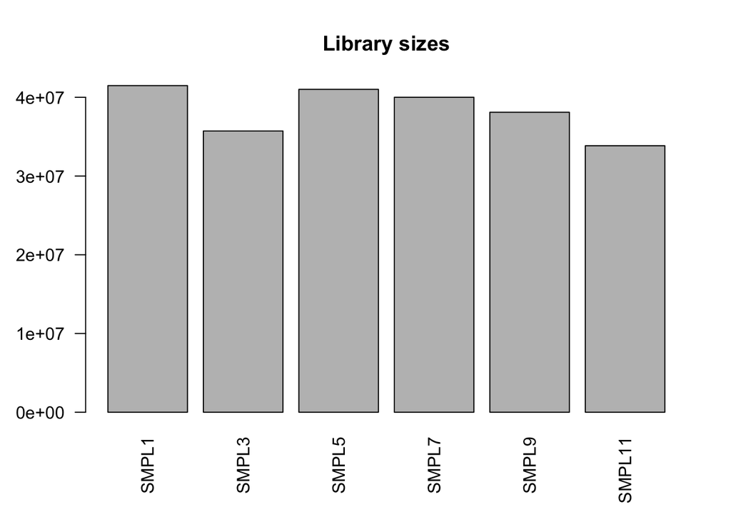

## QC (Quality Control)

Comparaison des distributions avant normalisation TMM

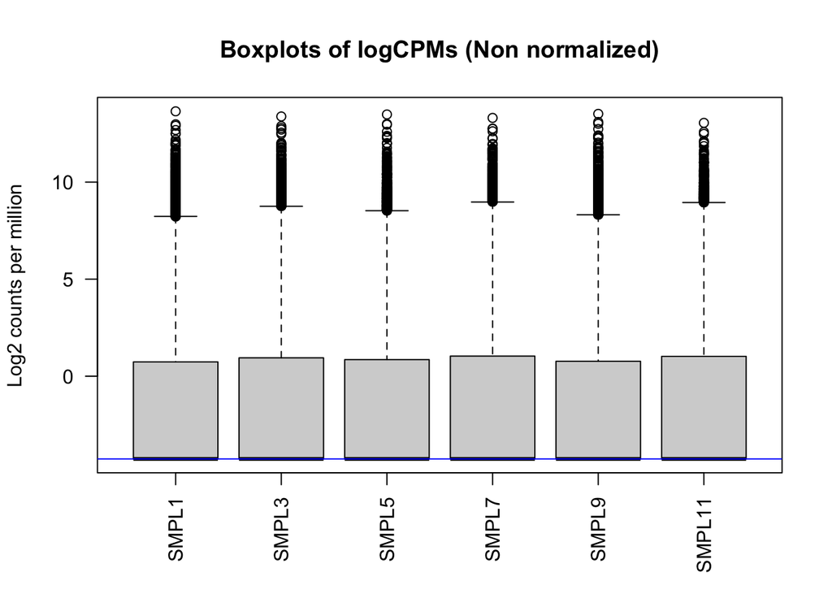

## QC (Quality Control)

Comparaison des distributions après normalisation TMM

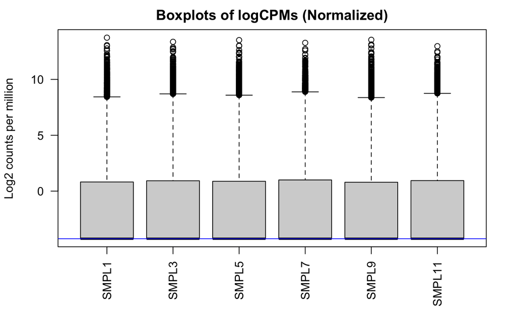

## QC (Quality Control)

Comparaison des distributions avant normalisation TMM

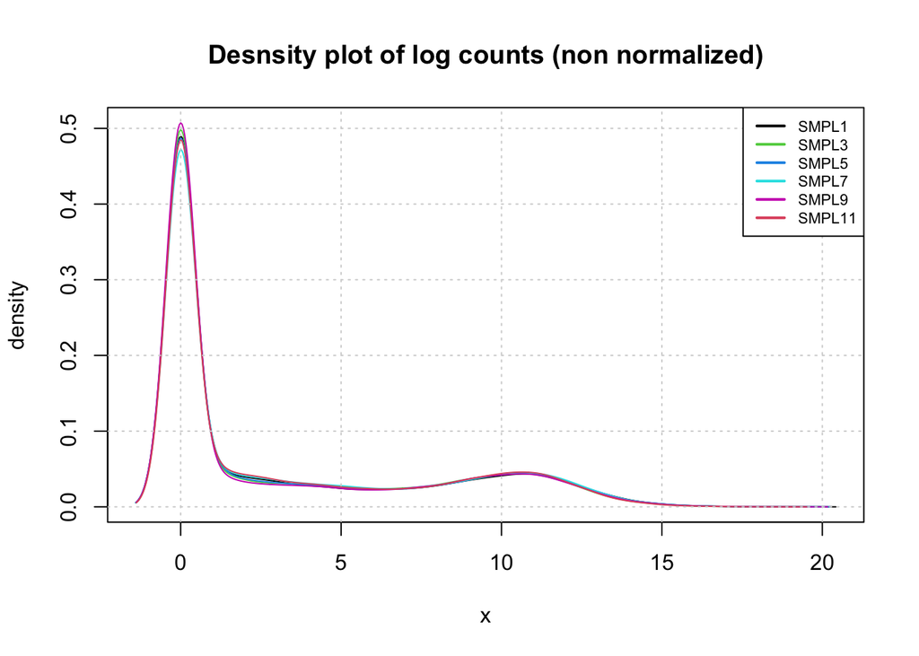

## QC (Quality Control)

Comparaison des distributions après normalisation TMM

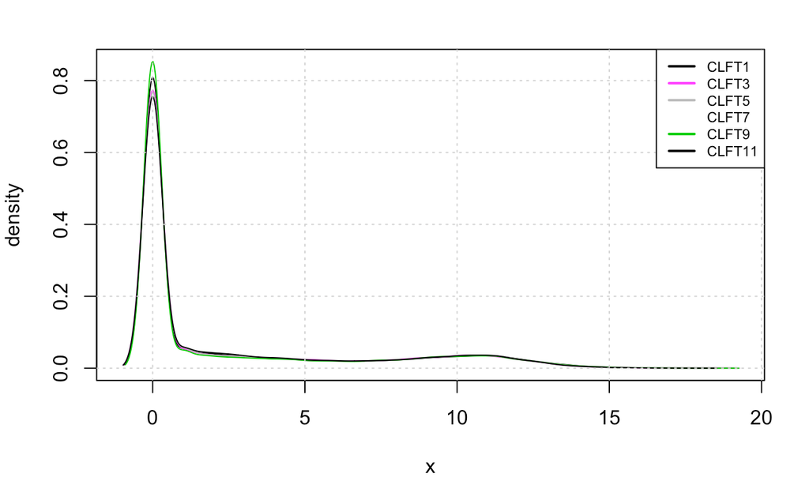

## Visualisation des profils d’expression: diagramme thermique

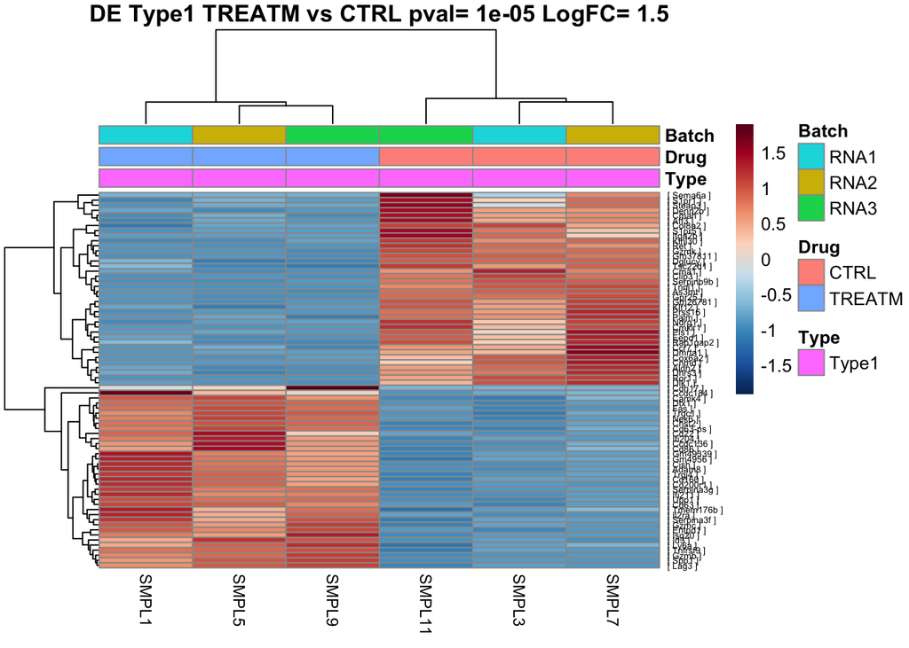